# Lecture 10: Examples

Mathematics and Statistics BS1515

Theodoros Arvanitopoulos

2025-11-28

# Example 1 - student test scores

### Problem overview

A sample of $49$ student test scores from a large class has a sample mean of $76.4$ and a standard deviation of $6.2$.

➡️ We want to test whether the true population mean score is $75$.

$$H_0: \mu = 75 \\
H_1: \mu \neq 75$$

This is a **two-tailed test** at the $\alpha = 0.05$ significance level.

# Example 1 - student test scores

### Problem overview

A sample of $49$ student test scores from a large class has a sample mean of $76.4$ and a standard deviation of $6.2$.

➡️ We want to test whether the true population mean score is $75$.

$$H_0: \mu = 75 \\
H_1: \mu \neq 75$$
This is a **two-tailed test** at the $\alpha = 0.05$ significance level.

### Problem solution

Use the formula to compute the test statistic with degrees of freedom $df = 49 - 1 = 48$:
$$t = \frac{\bar{x} - \mu_0}{s / \sqrt{n}} = \frac{76.4 - 75}{6.2 /
\sqrt{49}} = 1.58$$

**Determine the critical value**

From the t-distribution table $t_{0.025, \ 48} \approx 2.01$. So, we reject the null hypothesis if $t<-2.01 \quad \text{or} \quad t>2.01$.

**Make a decision**

Since $t = 1.58$ falls **between** $-2.01$ and $2.01$, we **do not reject** the null hypothesis. There is **insufficient evidence** to conclude that the true mean differs from $75$.

# Example 1 - distribution plot

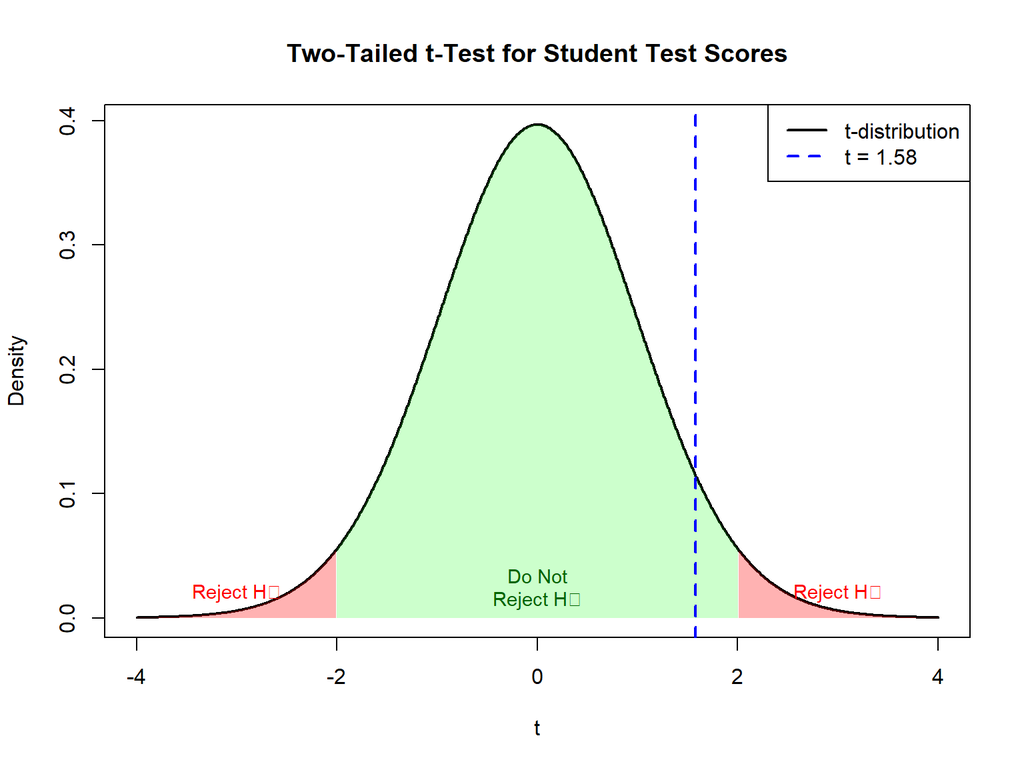

# Example 1 - problem solution using R

**Compute the test statistic**

```r
# Given values
x_bar <- 76.4     # sample mean
mu_0 <- 75        # hypothesized population mean
s <- 6.2          # sample standard deviation
n <- 49           # sample size
df <- n - 1       # degrees of freedom
alpha <- 0.05     # significance level (two-tailed)

# Calculate test statistic
t_stat <- (x_bar - mu_0) / (s / sqrt(n))
t_stat
```

```
## [1] 1.580645
```

**Determine critical values**

```r
t_crit <- qt(1 - alpha / 2, df)
t_crit
```

```
## [1] 2.010635
```

# Example 2 - two-tailed *t*-test - average hotel room cost

### Problem overview

A travel website claims the average cost of a hotel room in London is $£130$ per night. A sample of $25$ hotels shows an average rate of $£135$ with a standard deviation of $£9.20$.

➡️ Test whether the true average cost differs from $£130$ using a significance level of **α = 0.05**.

$$H_0: \mu = 130 \\
H_1: \mu \neq 130$$
This is a **two-tailed test** at the $\alpha = 0.05$ significance level.

# Example 2 - two-tailed *t*-test - average hotel room cost

### Problem overview

A travel website claims the average cost of a hotel room in London is $£130$ per night. A sample of $25$ hotels shows an average rate of $£135$ with a standard deviation of $£9.20$.

➡️ Test whether the true average cost differs from $£130$ using a significance level of **α = 0.05**.

$$H_0: \mu = 130 \\
H_1: \mu \neq 130$$
This is a **two-tailed test** at the $\alpha = 0.05$ significance level.

### Problem solution

Use the formula to compute the test statistic with degrees of freedom $df = n - 1 = 24$
$$t = \frac{\bar{x} - \mu_0}{s / \sqrt{n}} = \frac{135 - 130}{9.2 /
\sqrt{25}} = \frac{5}{1.84} \approx 2.72$$

**Determine the critical value**

From the *t*-distribution table $t_{0.025, \ 24} \approx 2.064$. So, we reject the null hypothesis if $t < -2.064 \quad \text{or} \quad t > 2.064$

**Make a decision**

Since $t = 2.72 > 2.064$, we reject the null hypothesis.

# Example 2 - distribution plot

[figure not shown]

# Example 2 - problem solution using R

**Compute the test statistic**

```r
# Given values
x_bar <- 135     # Sample mean
mu_0 <- 130      # Hypothesized population mean
s <- 9.2         # Sample standard deviation
n <- 25          # Sample size
df <- n - 1      # Degrees of freedom
alpha <- 0.05    # Significance level

# Calculate test statistic
t_stat <- (x_bar - mu_0) / (s / sqrt(n))
t_stat
```

```
## [1] 2.717391
```

**Determine critical values**

```r
t_crit <- qt(1 - alpha / 2, df)
t_crit
```

```
## [1] 2.063899
```

# Example 3 - two-tailed *z*-test using p-value

### Problem overview

Assume the population standard deviation is $\sigma=0.8$. We have a sample of size $n = 100$ with sample mean $\bar{x} = 2.84$.

➡️ We want to test whether the average number of TV sets in US homes is equal to $3$ test at significance level $\alpha = 0.05$.

$$H_0 : \mu = 3 \\
H_1 : \mu \neq 3$$
This is a **two-tailed test** at the $\alpha = 0.05$ significance level.

# Example 3 - two-tailed *z*-test using p-value

### Problem overview

Assume the population standard deviation is $\sigma=0.8$. We have a sample of size $n = 100$ with sample mean $\bar{x} = 2.84$.

➡️ We want to test whether the average number of TV sets in US homes is equal to $3$ test at significance level $\alpha = 0.05$.

$$H_0 : \mu = 3 \\
H_1 : \mu \neq 3$$
This is a **two-tailed test** at the $\alpha = 0.05$ significance level.

### Problem solution

Use the formula to compute the test statistic:
$$Z=\frac{\bar{x}-\mu}{\frac{\sigma}{\sqrt{n}}}=\frac{2.84-3}{\frac{0.8}{\sqrt{100}}}=-0.16/0.08=-2.0$$

**Determine the critical value**

From the $z$-distribution table, we reject the null hypothesis if $z<-1.96$ or $z>1.96$; otherwise, do not reject the null.

**Make a decision**

Here, $z=-2.0<-1.96$, so the test statistic is in rejection area. Thus, we reject the null and conclude that there is sufficient evidence that the mean number of TVs in US homes is not equal to $3$.

# Example 3 - calculate the *p*-value

➡️ How likely is it to see a sample mean of $2.84$ (or something further from the mean, in either direction) if the true mean is $\mu = 3.0$?

$\bar{x} = 2.84$ is translated to a $z$ score of $z = -2.0$:

$$P(z<-2.0)=0.0228 \\
P(z>2.0)=0.0228$$

So, $p-value=0.0228+0.0228=0.0456$ and given *p*-value$<0.05$,

→ this means that we can reject the null at significance level $\alpha=0.05$

More general:

- If *p*-value $< \alpha$, reject $H_0$
- If *p*-value $> \alpha$, do not reject $H_0$
- Since *p*-value $< 0.05$, we **reject the null hypothesis**
- Conclusion: There is evidence the average number of TVs is **not equal to 3**

# Example 3 - distribution plot

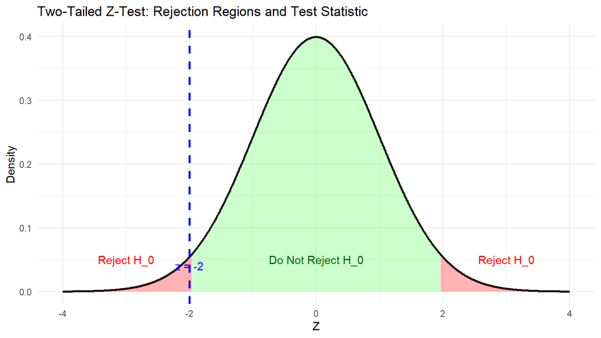

# Example 3 - problem solution using R

**Compute the test statistic**

```r
# Given values
mu_0 <- 3         # Hypothesized population mean
sigma <- 0.8      # Population standard deviation
x_bar <- 2.84     # Sample mean
n <- 100          # Sample size
alpha <- 0.05     # Significance level

# Calculate z statistic
z_stat <- (x_bar - mu_0) / (sigma / sqrt(n))
z_stat
```

```
## [1] -2
```

**Determine critical values**

```r
z_crit <- qnorm(1 - alpha / 2)
z_crit
```

```
## [1] 1.959964
```

**Determine p-values**

```r
p_val <- 2 * pnorm(-abs(z_stat))  # Two-tailed test
p_val
```

```
## [1] 0.04550026
```